# Seminar 5 Solved HOLA que hace pedazo de idiota

Paolo Ginatta

3/20/2019

##### First Excersice

Both the confidence interval and the hypothesis test are found in the prop.test. `alternative = "greater"` was used because the problem suggests that men have a *greater* probability of having the disease.

```r
prop.test(59,100, conf.level=0.90,alternative = "greater")
```

```
##
##  1-sample proportions test with continuity correction
##
## data:  59 out of 100, null probability 0.5
## X-squared = 2.89, df = 1, p-value = 0.04457
## alternative hypothesis: true p is greater than 0.5
## 90 percent confidence interval:
##  0.5209788 1.0000000
## sample estimates:
##    p
## 0.59
```

##### Second Excersice

In this problem a *paired sample* is presented with a *before* and an *after* levels of cholesterol, and it is required to test if the *after* is **smaller** than the *before* level. First, the samples are introduced.

```r
before <-c(200,210,330,240,260,300,245,210,190,225)
after <-c( 150,200,275,250,200,250,200,180,190,205)
```

Now we do a t test of the two variables with the option `paired=TRUE` enabled.

```r
t.test(before,after,paired = TRUE,alternative = "greater")
```

```
##
##  Paired t-test
##
## data:  before and after
## t = 3.9512, df = 9, p-value = 0.001674
## alternative hypothesis: true difference in means is greater than 0
## 95 percent confidence interval:
##  16.61788      Inf
## sample estimates:
## mean of the differences
##                      31
```

Note that the differences of the means are *before* - *after*. So, if the treatment is effective the result should be positive as *after* would be smaller, that’s why `alternative = "grater"` was used, since (if effective) it would have to be *grater* than 0. And, because the p-value is smaller than 5%, then it can be concluded that the null hypothesis *smaller or equal to 0* can be rejected, or in other words, it can be said that the treatment *is efective* with a **5%** significance level.

##### Third Excersise.

In this exercise it is asked to see whether the two samples’ averages are actually different. First, we introduce the data.

```r
linea <- c(10,30,32,23,23,24,20,18,39,35)
lineb <- c(12,28,30,20,25,31,15,12,22,24,40,30)
```

Now, the samples are compared graphically.

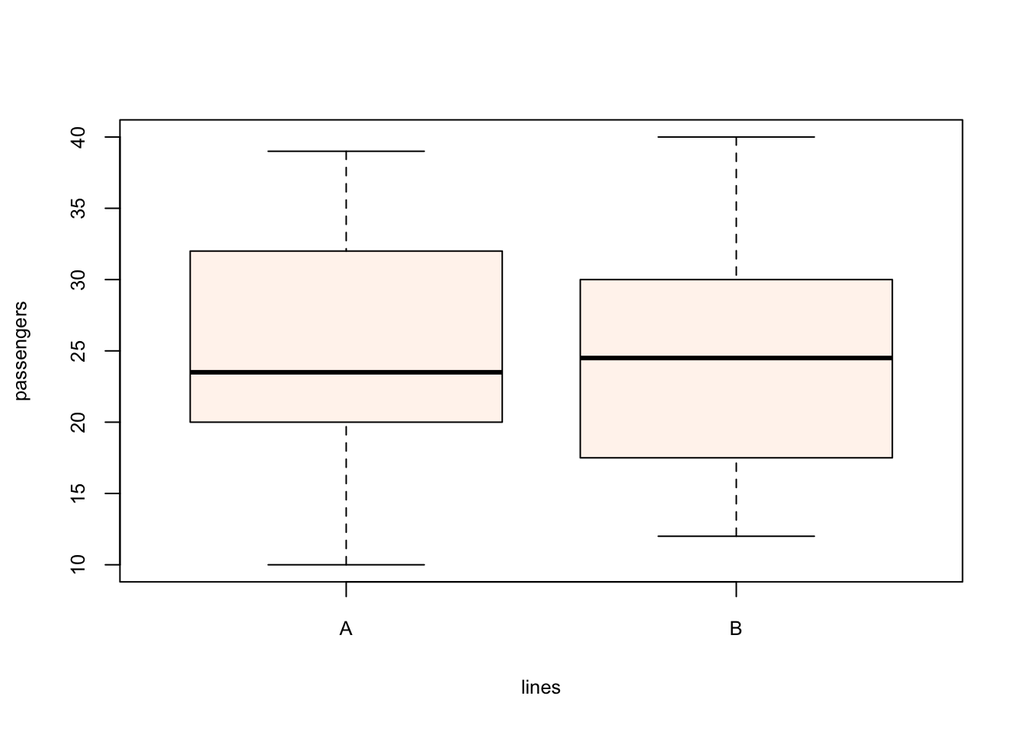

Figure: Boxplot of the samples of lines A and B

```r
boxplot(linea,lineb,names = c("A","B"),ylab = "passengers",xlab = "lines",
col = "seashell",cex.lab=0.80, cex.axis=0.80, cex.main=1.5, cex.sub=0.8)
```

It can be appreciated in the box plots that they are slightly different, but before doing a test to see if they actually are different (and not only by chance) a test to see if the variances are *equal* is needed, that is `var.test`.

```r
var.test(linea,lineb)
```

```
##
##  F test to compare two variances
##
## data:  linea and lineb
## F = 1.0559, num df = 9, denom df = 11, p-value = 0.9163
## alternative hypothesis: true ratio of variances is not equal to 1
## 95 percent confidence interval:
##  0.2943053 4.1309063
## sample estimates:
## ratio of variances
##           1.055938
```

As seen in the result of the test the ratio of the two variables is *not* equal to 1 by a little, in fact, the probability that this inequality happens, being actually equal to 1, is of 0.91, so we *cannot* reject the fact that they **variances** are equal.

Now that it is known that the variances are equal, a *two sample t-test* can be done in order to see if the means are actually different. Note that `var.equal = TRUE` is used since their equality has been already verified, and `mu = 0` since the problem asks to check only if the means are *diferent* from each other (alternative: *not* equal to 0).

```r
t.test(linea,lineb, mu=0, conf.level=0.90, var.equal=TRUE)
```

```
##
##  Two Sample t-test
##
## data:  linea and lineb
## t = 0.35999, df = 20, p-value = 0.7226
## alternative hypothesis: true difference in means is not equal to 0
## 90 percent confidence interval:
##  -4.991434  7.624768
## sample estimates:
## mean of x mean of y
##  25.40000  24.08333
```

The **sample estimates** at the end of the result shown above indicate that the means are different, but the 90% confidence interval of this difference traps **0** (that is the null hypothesis) and a **p-value** of **0.7226** suggests that the probability of this difference happening, being the means actually *equal*, is too high for it to be taken in consideration. As a result, it can be said with a 10% significance level, that means *are* equal.

##### Fourth Exercise

In this one, the same as exercise three has to be done but now between lines *A* and *C*. First, line C is introduced (line A was introduced in the previous exercise)

```r
linec <- c(32,39,35,30,37,28,34,33,25,30,37,33)
```

Now, the samples are compared graphically.

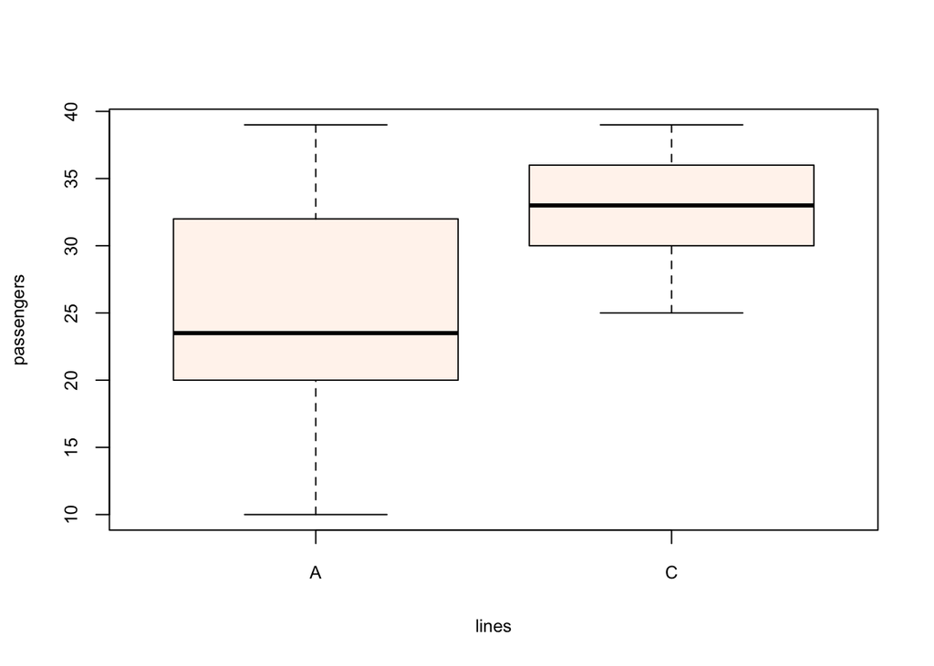

Figure: Boxplot of the samples of lines A and C

```r
boxplot(linea,linec,names = c("A","C"),ylab = "passengers",xlab = "lines",
col = "seashell",cex.lab=0.80, cex.axis=0.80, cex.main=1.5, cex.sub=0.8)
```

```r
var.test(linea,linec)
```

```
##
##  F test to compare two variances
##
## data:  linea and linec
## F = 4.5865, num df = 9, denom df = 11, p-value = 0.02075
## alternative hypothesis: true ratio of variances is not equal to 1
## 95 percent confidence interval:
##   1.278316 17.942610
## sample estimates:
## ratio of variances
##           4.586469
```

```r
t.test(linec,linea,mu=0,conf.level = 0.95,var.equal = TRUE)
```

```
##
##  Two Sample t-test
##
## data:  linec and linea
## t = 2.6229, df = 20, p-value = 0.0163
## alternative hypothesis: true difference in means is not equal to 0
## 95 percent confidence interval:
##   1.504602 13.195398
## sample estimates:
## mean of x mean of y
##     32.75     25.40
```